# ANTI-LGBTQ ANALYSIS ON TWITTER

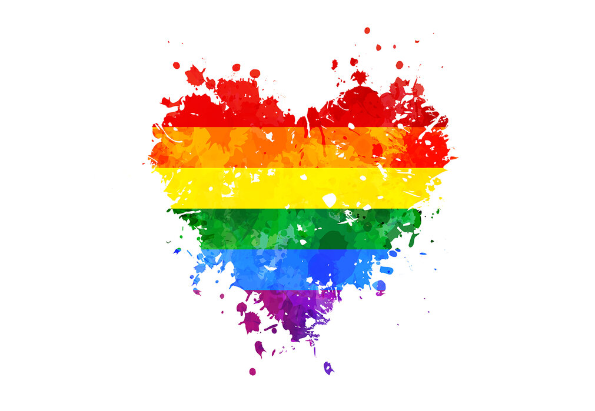

The rapid growth of social media has led to more and more people expressing their opinions online. Anyone can freely express their opinions on social media. Thousands of submissions occur every day on every social media. Opinions can be positive or negative on a topic, with positive sentiments expressing a good opinion, while negative sentiments express a bad opinion. It is safe to say that the Anti-LGBT community attracted a lot of people's interest to be discussed. This is evidenced by the many comments on social media, especially Twitter. The LGBT community has been fighting for equal rights for a very long time and it is also safe to say that the newer generations have been increasingly supportive as time progresses. Given that most people in this generation support the LGBT community, it goes without saying that there are also those who are opposed to it. Homosexual activities and relationships have gained legal sanctity, but the intriguing question is whether this historical verdict will enhance the social acceptance of the LGBT community or still they have miles to go.

The question is, what is the percentage of users on Twitter in the present who are anti-LGBTQ? We will use sentiment analysis of Twitter tweets to determine the percentage of anti-LGBTQ twitter users. Based on the tweets on Twitter, sentiment analysis can be carried out. As a result, we are encouraged to utilize Twitter social media as a source of data, which will then be analyzed via sentiment analysis, which is a method of assessing, extracting, and processing textual data automatically to determine the sentiment expressed in an opinion. Hence, this study is addressing the support factor by exploring the perception of social media users regarding the LGBTQ community on the Twitter platform. In short, in this study we are trying to classify our corpus into supporting tweets and opposing tweets. The algorithm used in conducting sentiment analysis in this study is Naïve Bayes and Random Forest.

**RESEARCH QUESTION**: Approximately what percentage of current twitter users are non-supporters of the LQBTQ community?

## DATA

**TRAINING DATA:** To train the classification models to predict anti-LGBTQ tweets, we will use the manually labeled dataset containing around 500 tweets as the training data. Tweepy is used to manually retrieve this dataset of 500 tweet ids and its corresponding text tweets. As a result, the final training csv file will contain three columns, namely tweet ID, tweet text linked to that id, and the label indicating positivity (1)/negativity (0).

```python
import pandas as pd
import nltk
import numpy as np
from pprint import pprint
from time import time

from sklearn.model_selection import GridSearchCV
from sklearn.pipeline import Pipeline
from sklearn.model_selection import train_test_split
from sklearn.datasets import make_classification
from sklearn.naive_bayes import MultinomialNB
from sklearn.multioutput import MultiOutputClassifier
from sklearn.ensemble import RandomForestClassifier
from sklearn.feature_extraction.text import TfidfVectorizer
from sklearn.feature_extraction.text import CountVectorizer
from sklearn.feature_extraction.text import TfidfTransformer
from sklearn.metrics import accuracy_score
from sklearn.metrics import f1_score, precision_score, recall_score
from IPython.display import Image
from sklearn.model_selection import KFold

import seaborn as sns
import matplotlib
import matplotlib.pyplot as plt
%matplotlib inline
from nltk.corpus import stopwords
nltk.download('stopwords')
data = pd.read_csv('Training_dataset_500.csv')
testing = pd.read_csv('Testing_dataset_500.csv')
```

```python
data
```

|  | id | text | label |
| --- | --- | --- | --- |
| 0 | 1520835097028608000 | RT @ErinInTheMorn: Oklahoma's House passes SB6... | 1 |
| 1 | 1520835159288864769 | RT @ResisterSis20: America goes to the polls i... | 1 |
| 2 | 1520835159871954945 | RT @Noah_Villaverde: Kevin Feige emphasizes th... | 1 |
| 3 | 1520835168365338625 | @Bored_Insomniac @Flipper65 @Brent_Johnson14 @... | 1 |
| 4 | 1520835169112174593 | RT @tfjshi: i loved how they changed the scrip... | 1 |
| ... | ... | ... | ... |
| 495 | 1520911366915297281 | @TabbyWesa Picked on? The 1/3 is parents physi... | 1 |
| 496 | 1520911377321414656 | @lokisvinyl THE WAY SZA HAS BASICALLY SAID TWI... | 1 |
| 497 | 1520911421734891526 | @johnpavlovitz There is nothing virtuous about... | 1 |
| 498 | 1520911426130518017 | @trangtroy_ 2/n around. There are so many peop... | 1 |
| 499 | 1520911442429550593 | @fleaflofloyd Yeah! And that’s what I love abo... | 1 |

500 rows × 3 columns

```python
testing
```

|  | id | text |
| --- | --- | --- |
| 0 | 1520911442429550593 | @fleaflofloyd Yeah! And that’s what I love abo... |
| 1 | 1520911426130518017 | @trangtroy_ 2/n around. There are so many peop... |
| 2 | 1520911421734891526 | @johnpavlovitz There is nothing virtuous about... |
| 3 | 1520911377321414656 | @lokisvinyl THE WAY SZA HAS BASICALLY SAID TWI... |
| 4 | 1520911366915297281 | @TabbyWesa Picked on? The 1/3 is parents physi... |
| ... | ... | ... |
| 495 | 1520876339510734848 | @TomFitton This man wakes up every day and tel... |
| 496 | 1520876332111962112 | @Bundgaard1337 @MichelleLKascha @TheElliotPage... |
| 497 | 1520876313162117120 | @Jodyscott31Jody It’s the self-loathing, repre... |
| 498 | 1520876305377546242 | @ManicPixJeepGrl @Harukawai3 @jumpdrive4 @_Tor... |
| 499 | 1520876303951572993 | trying to be a gay pirate tbh |

500 rows × 2 columns

## ANALYSIS

As a part of this study, we will use Naive Bayes classifier and Random Forest to train and test our model to analyze and predict tweets. Text classification, for example, can use these two classifiers with discrete features.

klearn is a simple and efficient tool used for predictive data analysis that is built on NumPy, SciPy and matplotlib. Matplotlib is used to visualize the analyzed data. “sklearn.naive_bayes.MultinomialNB” and “sklearn.ensemble.RandomForestClassifier” are used to train the model to classify the tweets into the two categories, i.e., positive (1) and negative (0). After training the model and labeling the tweets, matplotlib is used to plot a bar graph that represents the percentage of each type of information (whether positively or negatively opinionated). Note that there will be a few rows with null values due to reasons such as data retrieval failure, etc. and such rows will be removed from the dataset while training to avoid affecting the model accuracy. We use the evaluate and predict functions to train the model using various libraries and pipelines. We retrieve the best fitting model and the best parameters that acquires the best accuracy for that particular model as well.

```python
def evaluate(test_labels, predictions):
    precision = precision_score(test_labels, predictions, average='micro')
    recall = recall_score(test_labels, predictions, average='micro')
    f1 = f1_score(test_labels, predictions, average='micro')
    print("Micro-average quality numbers")
    print("Precision: {:.4f}, Recall: {:.4f}, F1-measure: {:.4f}".format(precision, recall, f1))

    precision = precision_score(test_labels, predictions, average='macro')
    recall = recall_score(test_labels, predictions, average='macro')
    f1 = f1_score(test_labels, predictions, average='macro')

    print("Macro-average quality numbers")
    print("Precision: {:.4f}, Recall: {:.4f}, F1-measure: {:.4f}".format(precision, recall, f1))
```

```python
def predict(X, y, testing, classifier, parameters):
    train_docs, test_docs, Y_train, Y_test = train_test_split(X, y, test_size=0.3, random_state=42)
    cachedStopWords = nltk.corpus.stopwords.words('english')

    pipeline = Pipeline([
        ('vect', CountVectorizer(stop_words=cachedStopWords)),
        ('tfidf', TfidfTransformer()),
        ('clf', classifier)
    ])

    cv = KFold(n_splits=3, random_state=42, shuffle=True)
    # added return_train_score=True
    grid_search = GridSearchCV(pipeline, parameters, cv=cv, n_jobs=-2, verbose=1, scoring="f1_micro", return_train_score=True)

    print("Performing grid search...")
    print("pipeline:", [name for name, _ in pipeline.steps])
    print("parameters:")
    pprint(parameters)
    t0 = time()
    grid_search.fit(train_docs, Y_train)
    print("done in %0.3fs" % (time() - t0))
    print()
    #print("grid_search.cv_results_", grid_search.cv_results_)
    #estimator : estimator object. This is assumed to implement the scikit-learn estimator interface.
    #            Either estimator needs to provide a score function, or scoring must be passed.
    #Accuracy is the default for classification; feel free to change this to precision, recall, fbeta
    print("Best score: %0.3f" % grid_search.best_score_)
    print("Best parameters set:")
    best_parameters = grid_search.best_estimator_.get_params()
    for param_name in sorted(parameters.keys()):
        print("\t%s: %r" % (param_name, best_parameters[param_name]))

    #Test on Heldlout test set
    preds = grid_search.best_estimator_.predict(test_docs)
    print(np.unique(preds, return_counts=True))
    print("--------------------------------------------------------------------")
    evaluate(Y_test, preds)
    print("--------------------------------------------------------------------")
    preds_train = grid_search.best_estimator_.predict(train_docs)
    print(np.unique(preds_train, return_counts=True))
    testing_no_null = testing.drop(testing.loc[testing.text.isnull()].index, axis=0)
    X_test = testing_no_null['text']
    #preds = best_estimator_mnb.predict(X_test)
    x, y = np.unique(preds, return_counts=True)
    print (x, y)

    width = 0.35
    fig, ax = plt.subplots()

    pps = ax.bar(x, y, width, align='center')
    plt.xticks([0, 1])

    for p in pps:
        value = round(p.get_height() / sum(y), 4) * 100
        height = p.get_height()
        ax.text(x=p.get_x() + p.get_width() / 2, y=height+1.5, s="{}%".format(value), ha='center')
    plt.show()
    X_test = testing_no_null['text']
    return grid_search.best_estimator_
```

```python
data_no_null = data.drop(data.loc[data.text.isnull()].index, axis=0)
X_train = data_no_null['text']
y_train = data_no_null['label']
data_no_null.shape
```

```
(500, 3)
```

## MODELS

### Naive Bayes

Naive Bayes is a basic but effective probabilistic classification model in machine learning that draws influence from Bayes Theorem. In Statistics, naive Bayes classifiers are a family of simple probabilistic classifiers based on applying Bayes’ theorem with strong (naïve) independence assumptions between the features. They are among the simplest Bayesian network models, but coupled with kernel density estimation, they can achieve high accuracy levels.

```
Performing grid search...
pipeline: ['vect', 'tfidf', 'clf']
parameters:
{'clf__alpha': (0.001, 0.01, 0.1),
 'tfidf__norm': ('l1', 'l2'),
 'tfidf__use_idf': (True, False),
 'vect__max_df': (0.5, 0.75, 1.0),
 'vect__max_features': (None, 200, 500),
 'vect__ngram_range': ((1, 1), (1, 2))}
Fitting 3 folds for each of 216 candidates, totalling 648 fits
done in 4.363s

Best score: 0.629
Best parameters set:
	clf__alpha: 0.1
	tfidf__norm: 'l1'
	tfidf__use_idf: False
	vect__max_df: 0.5
	vect__max_features: 200
	vect__ngram_range: (1, 2)
(array([0, 1]), array([ 18, 132]))
--------------------------------------------------------------------
Micro-average quality numbers
Precision: 0.6000, Recall: 0.6000, F1-measure: 0.6000
Macro-average quality numbers
Precision: 0.5568, Recall: 0.5250, F1-measure: 0.4802
--------------------------------------------------------------------
(array([0, 1]), array([ 73, 277]))
[0 1] [ 18 132]
```

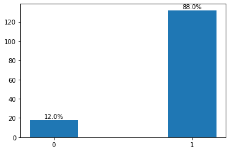

```python
parameters = { #listed in the form of "step__parameter", e.g, clf__penalty
    'vect__max_df': (0.5, 0.75, 1.0),
    'vect__max_features': (None, 200,500),
    'vect__ngram_range': ((1, 1), (1, 2)),  # unigrams (single words) or bigrams (or sequence of words of length 2)
    'tfidf__use_idf': (True, False),
    'tfidf__norm': ('l1', 'l2'),
    'clf__alpha': (0.001, 0.01, .1),
}
best_estimator_mnb = predict(X_train, y_train, testing, MultinomialNB(), parameters)
```

### Random Forest

Library: https://scikit-learn.org/stable/modules/generated/sklearn.ensemble.RandomForestClassifier.html

Random forest is a Supervised Machine Learning Algorithm that is used widely in Classification and Regression problems. It builds decision trees on different samples and takes their majority vote for classification and average in case of regression.

Random forest works on the Bagging principle. Bagging, also known as Bootstrap Aggregation is the ensemble technique used by random forest. Bagging chooses a random sample from the data set. Hence each model is generated from the samples (Bootstrap Samples) provided by the Original Data with replacement known as row sampling. This step of row sampling with replacement is called bootstrap. Now each model is trained independently which generates results. The final output is based on majority voting after combining the results of all models. This step which involves combining all the results and generating output based on majority voting is known as aggregation.

Steps involved in random forest algorithm:

- Step 1: In Random forest n number of random records are taken from the data set having k number of records.
- Step 2: Individual decision trees are constructed for each sample.
- Step 3: Each decision tree will generate an output.
- Step 4: Final output is considered based on Majority Voting or Averaging for Classification and regression respectively.

```
Performing grid search...
pipeline: ['vect', 'tfidf', 'clf']
parameters:
{'clf__criterion': ('gini', 'entropy'),
 'clf__max_depth': (5, 10),
 'clf__min_samples_leaf': (3, 10),
 'clf__min_samples_split': (5, 10),
 'clf__n_estimators': (10, 100),
 'tfidf__norm': ('l1', 'l2'),
 'tfidf__use_idf': (True, False),
 'vect__max_df': (0.5, 0.75, 1.0),
 'vect__max_features': (None, 200, 500),
 'vect__ngram_range': ((1, 1), (1, 2))}
Fitting 3 folds for each of 2304 candidates, totalling 6912 fits
done in 90.163s

Best score: 0.611
Best parameters set:
	clf__criterion: 'entropy'
	clf__max_depth: 5
	clf__min_samples_leaf: 3
	clf__min_samples_split: 5
	clf__n_estimators: 10
	tfidf__norm: 'l1'
	tfidf__use_idf: False
	vect__max_df: 0.5
	vect__max_features: 500
	vect__ngram_range: (1, 1)
(array([0, 1]), array([  5, 145]))
--------------------------------------------------------------------
Micro-average quality numbers
Precision: 0.6067, Recall: 0.6067, F1-measure: 0.6067
Macro-average quality numbers
Precision: 0.6034, Recall: 0.5139, F1-measure: 0.4206
--------------------------------------------------------------------
(array([0, 1]), array([ 24, 326]))
[0 1] [  5 145]
```

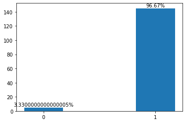

```python
parameters = { #listed in the form of "step__parameter", e.g, clf__penalty
    'vect__max_df': (0.5, 0.75, 1.0),
    'vect__max_features': (None, 200,500),
    'vect__ngram_range': ((1, 1), (1, 2)),  # unigrams (single words) or bigrams (or sequence of words of length 2)
    'tfidf__use_idf': (True, False),
    'tfidf__norm': ('l1', 'l2'),
    'clf__n_estimators': (10, 100),
    'clf__max_depth': (5, 10),
    'clf__min_samples_leaf': (3, 10),
    'clf__min_samples_split': (5, 10),
    'clf__criterion': ('gini', 'entropy'),
}
best_estimator_rfc = predict(X_train, y_train, testing, RandomForestClassifier(bootstrap=True, random_state=42), parameters)
```

## RESULTS AND CONCLUSIONS

To summarize, the following workflow was used for the analysis:

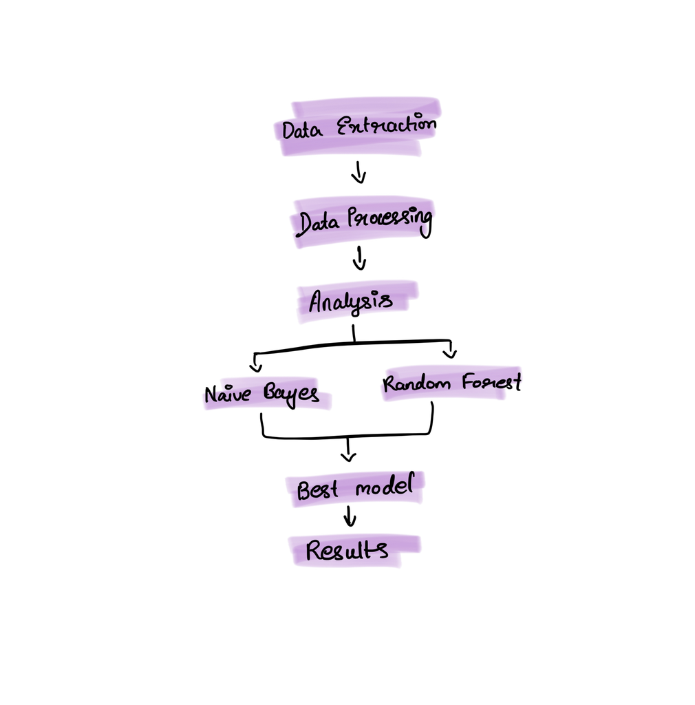

## REFERENCES

**Cover page image credits:**

• https://www.photowall.com/us/lgbt-grungy-heart-wallpaper • https://unsplash.com/photos/Ur_NzyKfCo4

**Introduction:**

[1] “C Tweeting in Support of LGBT? A Deep Learning Approach”, https://www.sentic.net/tweeting-in-support-of-lgbt.pdf

[2] “Sentiment Analysis of Social Media Twitter with Case of AntiLGBT Campaign in Indonesia using Naïve Bayes, Decision Tree, and Random Forest Algorithm”, Veny Amilia Fitri*, Rachmadita Andreswari, Muhammad Azani Hasibuan.

[3] Fahrur Rozi, Imam, Sholeh Hadi Pramono, and Erfan Achmad Dahlan. (2012) “Implementasi Opinion Mining (Analisis Sentimen) untuk Ekstraksi Data Opini Publik pada Perguruan Tinggi [Title in English: The Implementation of Opinion Mining to Extract Public Opinion Data in Higher Education].” Jurnal EECCIS 37.

**Data:**

[4] Twitter website, https://twitter.com/

[5] “How do I get twitter data set?”, https://www.researchgate.net/post/How-do-I-get-twitter-data-set

**Analysis:**

[6] “Naïve Bayes Classifier”, https://en.wikipedia.org/wiki/Naive_Bayes_classifier

[7] “Random Forest”, https://en.wikipedia.org/wiki/Random_forest

[8]“Understanding random forest”, Analytics Vidhya, https://www.analyticsvidhya.com/blog/2021/06/understanding-random-forest/

[9] Ghiassi, M., and S. Lee. (2018) “A Domain Transferable Lexicon Set for Twitter Sentiment Analysis.” Expert Systems With Applications. pp. 197-216